# Module 13 Lecture - F Distribution and One-Way ANOVA

Introduction to Statistical Methods

Quinton Quagliano, M.S., C.S.P

Department of Educational Psychology

# 1 Overview and Introduction

Agenda

1 Overview and Introduction

2 The F Distribution

3 The F Ratio

4 One-way ANOVA

5 Conclusion

## 1.1 Textbook Learning Objectives

- Interpret the F probability distribution as the number of groups and the sample size change.
- Discuss one use for the F distribution: one-way ANOVA
- Conduct and interpret one-way ANOVA.

## 1.2 Instructor Learning Objectives

- Appreciate the ANOVA as another test in your toolbox alongside the other tests for dealing with categorical and continuous outcome variables
- Understand the F-distribution as another practical distribution for deriving inferences and conclusions

## 1.3 Introduction

- **Discuss: When we needed to compare the averages of two groups on a continuous variable, what statistical test would we use?**
- While we’ve already covered how to test differences between two groups, now we need to consider the scenario with three or more groups on some outcome
  - Examples:
    - Comparing class outcomes for those in hybrid, in-person, or online sections
    - Comparing students on three different tracks in high school: regular, advanced, or remedial
- When we are comparing three categorical groups on some numeric, continuous outcome, we will employ the one-way ANOVA, standing for **Analysis of Variance (ANOVA)**
  - ANOVA is a broad family of techniques with many applications and extensions
  - We are looking at the one-way ANOVA as a specific use of this technique
- **Important: This is very similar to how we introduced simple linear regression - there are many more advancements on top of what you learn in this class, which you will encounter in more advanced statistics classes!**
- Why not use a bunch of t-tests across the 3 groups instead of this new complicated method?
  - Problem: It raises our Type I error rate
  - This is something done as part of ANOVA in post-hoc testing, but that won’t be covered here
- **Discuss: Describe what Type I errors are**
- Our previous tests all made use of specific, practical distributions for determining significance:
  - z-tests $\rightarrow$ normal distribution
  - t-tests $\rightarrow$ t-distribution
  - $\chi^2$ tests $\rightarrow$ $\chi^2$ distribution
  - The ANOVA family will introduce a new distribution: the F-distribution
- We’ll start by describing the F-distribution itself, then the F-ratio/statistic that we compute, and then finally the application within the One-way ANOVA

# 2 The F Distribution

Agenda

1 Overview and Introduction

2 The F Distribution

3 The F Ratio

4 One-way ANOVA

5 Conclusion

## 2.1 Introduction

- The **F-distribution** was developed by Sir Ronald Fisher and is a unique distribution applied often for the ANOVA family of statistical tests
  - In notation it is given as $F \sim F_{df(num),df(denom)}$ where:
  - $df(num) \rightarrow df_{between}$ and $df(denom) \rightarrow df_{within}$
  - Example: $F \sim F_{2, 24}$ has:
    - $df_{between} = 2$
    - $df_{within} = 24$
- **Important: Hold on just a second, *two* different degrees of freedom? Yes! We'll discuss more about why that is in our discussion on the F-ratio itself**
- The F-distribution actually consists of values that are squares of the t-distribution, and is derived from the t-distribution
  - How exactly Fisher proved that is *way* beyond the scope of this class
- **Discuss: Recall, what exactly is the distinction that makes the t-distribution different and useful over the normal distribution? The F-statistic benefits from this the same!**

## 2.2 Additional Facts About the F Distribution

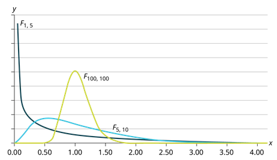

- The curve is not symmetrical but skewed to the right.
  - Thus, it has a more similar look to the chi-squared distribution, compared to the t-distribution
- There is a different curve for each set of dfs.
  - Once again, similar to chi-squared
- The F statistic is greater than or equal to zero.
- **Discuss: After you work through the F-ratio section and calculation below, return to this section and try to explain, using the formula, why this F is always greater than or equal to zero**
- As the degrees of freedom for the numerator and for the denominator get larger, the curve approximates the normal distribution.
  - Remember, the $df_{between} \rightarrow$ numerator and the $df_{within} \rightarrow$ denominator

# 3 The F Ratio

Agenda

1 Overview and Introduction

2 The F Distribution

3 The F Ratio

4 One-way ANOVA

5 Conclusion

## 3.1 Introduction

- The **F-ratio** is just another name for the F statistic that results from the test we run
  - The F-ratio/statistic we get is a ratio of:
    - The variances between samples
    - The variances within samples
    - It’s formula is given as:

$$F = \frac{MS_{between}}{MS_{within}}$$

- Well describe what the $MS$ means here in a second

## 3.2 Between & Within Variation

- For **Variances between samples**, we are considering how much difference there is between the 3 or more groups we are comparing to one another
  - This may also be known as “variation due to treatment” or “explained variation”
  - This will be represented computationally as the $MS_{between}$ or the **mean square**
  - This is the numerator of the F-ratio formula
- In the case of **Variances within samples**, we example how much variation there is within each of the groups we are comparing to one another
  - This may also be known as “variation due to error” or “unexplained variation”
  - This will be represented as $MS_{within}$ in the following formula
  - This is the denominator of the F-ratio formula

## 3.3 Calculation of the F-ratio/statistic

- We are *not* going to calculate F by hand, as it is very time-consuming, albeit plenty possible
  - However, you should still follow along and make sure you can see the flow of information as we substitute numbers in these calculations

### Overall F Calculation

$$F = \frac{MS_{between}}{MS_{within}}$$

### Between-group Calculations

$$MS_{between} = \frac{SS_{between}}{df_{between}}$$

$$df_{between} = k - 1$$

$$SS_{between} = \sum{[\frac{(s_j)^2}{n_j}] - \frac{(\sum{s_j})^2}{n}}$$

- Where
  - $SS_{between}:$ Sum of squares between groups
  - $SS_{total}:$ Sum of squares total
  - $df_{between}:$ degrees of freedom between groups
  - $k:$ the number of groups
  - $n:$ total sample size
  - $n_j:$ the size of $j^{th}$ group
  - $s_j:$ sum of values of $j^{th}$ group

### Within-group Calculations

$$MS_{within} = \frac{SS_{within}}{df_{within}}$$

$$df_{within} = n - k$$

$$SS_{within} = SS_{total} - SS_{between}$$

- Where
  - $SS_{within}:$ Sum of squares between groups
  - $SS_{between}:$ Sum of squares between groups
  - $SS_{total}:$ Sum of squares total
  - $df_{within}:$ degrees of freedom between groups
  - $n:$ total sample size

# 4 One-way ANOVA

Agenda

1 Overview and Introduction

2 The F Distribution

3 The F Ratio

4 One-way ANOVA

5 Conclusion

## 4.1 Introduction

- **Important: In the prior calculations, we covered the mathematical computation in a one-way ANOVA, but this next part will cover the more conceptual side of things.**
- The goal of the one-way ANOVA is to determine if there are significant differences between multiple group means
  - This is done by examining the variances of the groups (as we previously discussed as part of The F Ratio)
- This is how we will practically use the F-distribution

## 4.2 Assumptions

- Much like the other tests, we need to be mindful of several assumptions that underline this statistical test
- These assumptions are:
  - Each population from which a sample is taken is assumed to be normal.
  - All samples are randomly selected and independent.
  - The populations are assumed to have equal standard deviations (or variances).
  - The factor is a categorical variable.
  - The response is a numerical variable.

## 4.3 Null and Alternative Hypotheses

- In a one-way ANOVA, the null hypothesis is as follows:
  - $H_0: \mu_1 = \mu_2 = \mu_3 ... = \mu_k$
  - $H_A:$ At least two of the group means $\mu_1,\mu_2,\mu_3,..., \mu_k$ are not equal
- **Important: Be *very* careful in how you phrase the alternative hypothesis for this test, it looks a little bit different than the other tests we've covered before!**
- Effectively, a statistically significant F-statistic only tells us that a difference exists somewhere, but not where that difference lies
  - More explanation on this in the Extensions section!
- **Discuss: What is the name of type of the following plots?**

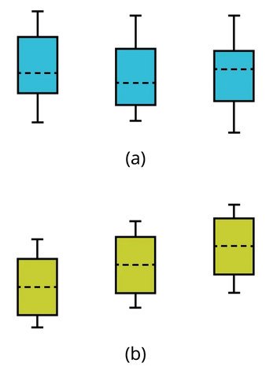

## 4.4 Extensions

- Of course, this is only the tip of the iceberg
- One question that the ANOVA alone doesn't answer: which of the groups are different?
  - If we have a significant one-way ANOVA test, then we can follow up with **post-hoc testing**, which can tell us which groups exactly are different than one another
- There is also the **two-way ANOVA**, which allows us to compare two or more independent variables and their combined and interacting impact on a single dependent variable in two-way Analysis of Variance.
  - While beyond the scope of this class, interactions are an incredibly important part of a lot of more complicated studies
- Finally, there is the **repeated-measures ANOVA**
- **Discuss: Which of the previous tests we talked about dealt with comparing two sets of measurements, taken at two separate time points, on the same sample?**

# 5 Conclusion

Agenda

1 Overview and Introduction

2 The F Distribution

3 The F Ratio

4 One-way ANOVA

5 Conclusion

## 5.1 Recap

- We can think of a one-way ANOVA as being similar to an independent-samples t-test, but for more than 2 groups. Just note the differences in the null/alternative hypotheses setup
- There are some important extensions and other applications of the ANOVA that we did not comprehensively cover here. However, they do still employ the F-distribution and have the underlying focus on comparing variances to make conclusions about differences between groups
- The F-distribution adds to the other practical distributions employed as part of hypothesis testing, such as the t-distribution and chi-squared distribution. Just like those, it allows us to conclude whether a null hypothesis can be rejected or retained.

## 5.2 Lecture Check-in

- Make sure to complete any lecture check-in tasks associated with this lecture!

[figure not shown]

Module 13 Lecture - F Distribution and One-Way ANOVA || Introduction to Statistical Methods